# OOPS

- Defining a Class

## What is a class and how does it work

**Refering to the DEMO code below***

- User Defined data type
- We can then defined an instance of if by defining an object of this type
- These variables (objects), are also created in STACK

```python
#include <iostream>
#include <climits>
#include <math.h>
using namespace std;
```

```python
class Rectangle{
public:
    int length;
    int breadth;

    int area(){
        return length * breadth;
    }

    int perimeter(){
        return 2 *( length + breadth);
    }

}
```

```python
Rectangle r1, r2;
```

## How much memory space (bytes) will this object occupy?

We need to look at the data members (the data variables defined in class) that is used in class:

```
int length;
int breadth;
int area(){..}
int perimeter(){}
```

int takes 4 bytes x 2 (lenght and breath) = 8 bytes.

Note functions will not occupy any memeory space.

So size of this class (Rectangle) = 8 bytes.

```
r1 = 8 bytes
r2 = 8 bytes
```

Note the class, which is the blueprint, does NOT occupy any memory, only the instance, i.e the object occupies memory

```python
r1.length=10;
r1.breadth=5;
```

## How to access member of class

We use the dot (.) operator

But by default all member are private.

So we need to add **public:**, and every thing after this declaration becomes accessible from outside the class

```
public:
    int length;
    int breadth;
    ....
    ....
```

(This is how the learning will occur: only when things are needed we add it, so I will remember it better next time. By adding public from start would not have made sense. This wil be the learning approach taken)

```python
cout<<r1.area()<<endl;
cout<<r1.perimeter()<<endl;
```

```
50
30
```

### Remember functions will NOT occupy any memory

```python
r2.length=15;
r2.breadth=10;
```

```python
cout<<r2.area()<<endl;
cout<<r2.perimeter()<<endl;
```

```
150
50
```

## Objects of Class

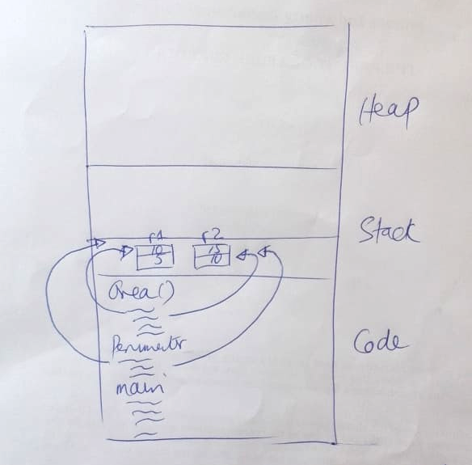

## How does it work

Although we defining r1 and r2 which has its own **area** and **perimeter**, in the code section its only defined **ONCE**, and there is class declaration in the code section.

I the stack, the objects data members does have memory allocated to it.

So these objects are created in STACK

But objects can also be created in HEAP, with use of pointers.

Lets explore...next lesson..